# EVAR practice and outcomes - all EVAR

Indication, number, gender, age, year and stent-graft used

Martin Hennessy, Collum O’Hare, Tom Gordon, Sophie Adams

22/12/2019

# 1 Details about all EVAR performed

## 1.1 Timescale covered and number of EVAR

- This document covers EVAR performed between 1996-09-19 and 2019-12-19 for any indication
- This comprises **1038** EVAR
- Of these, the numbers are split among the Health Boards as detailed below:

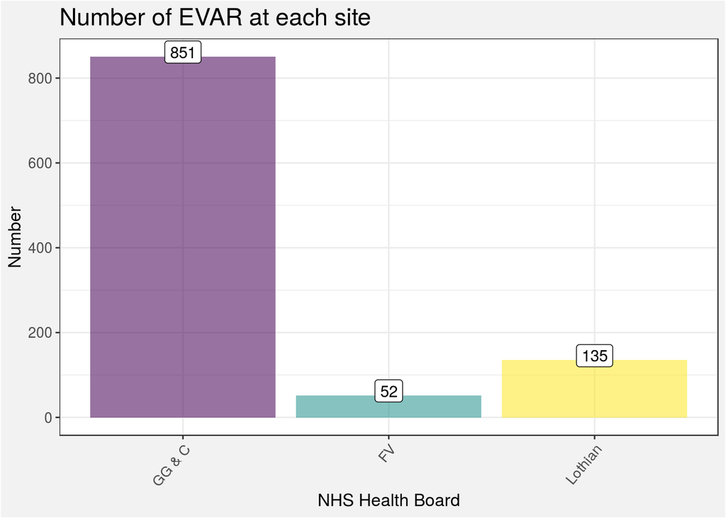

All years; FV = Forth Valley, GG & C = Greater Glasgow and Clyde

## 1.2 Indication

### 1.2.1 Number of EVAR for each indication

- Both ruptured and symptomatic aneurysms are judged by available clinical information
- “Open repair issue” is usually pseudoaneurysm formation

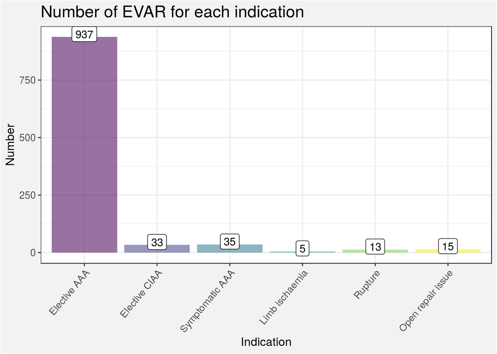

### 1.2.2 Numbers of EVAR for each indication at each site

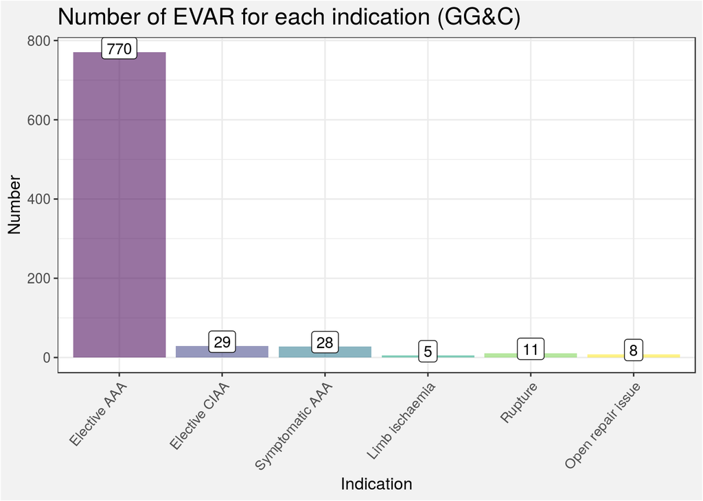

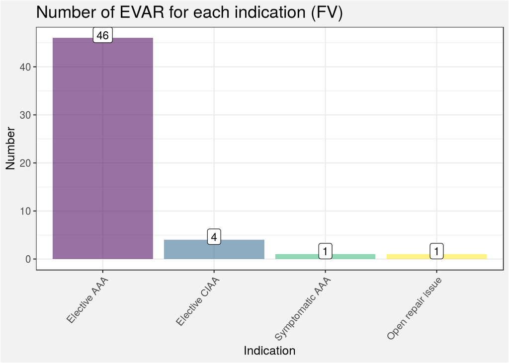

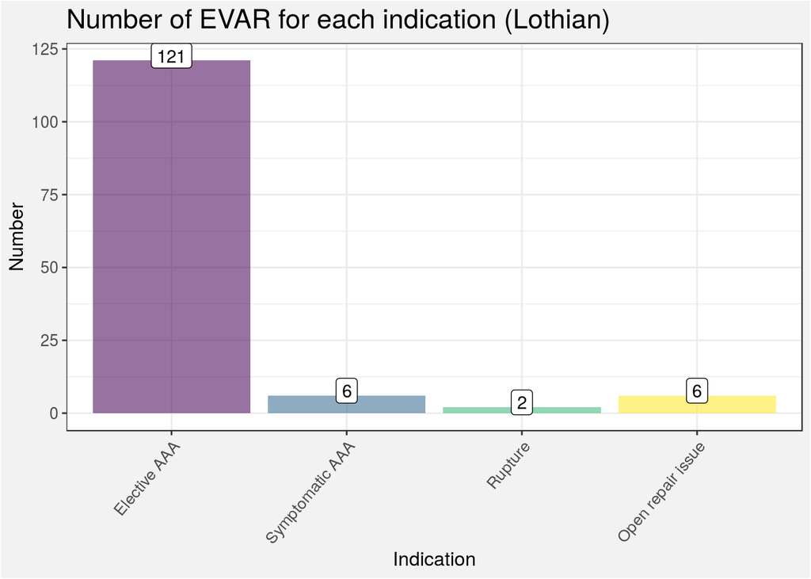

## 1.3 Gender

### 1.3.1 Number of EVAR performed by gender

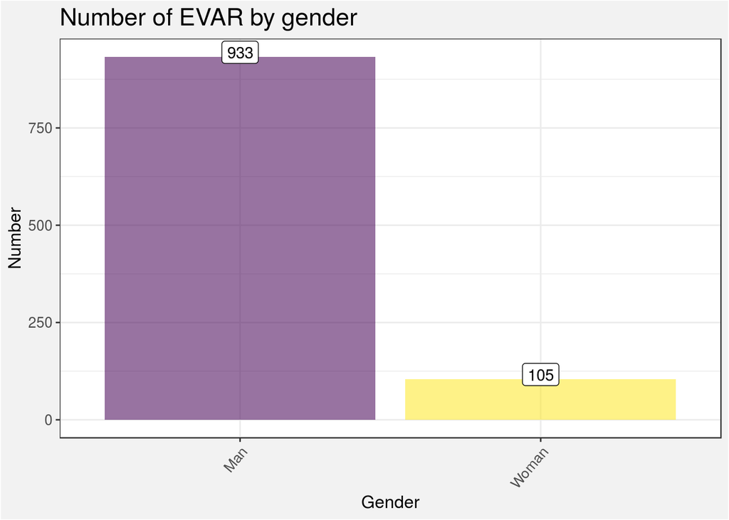

- 10.1% of EVAR have been performed in women

### 1.3.2 Number of EVAR performed by gender at each site

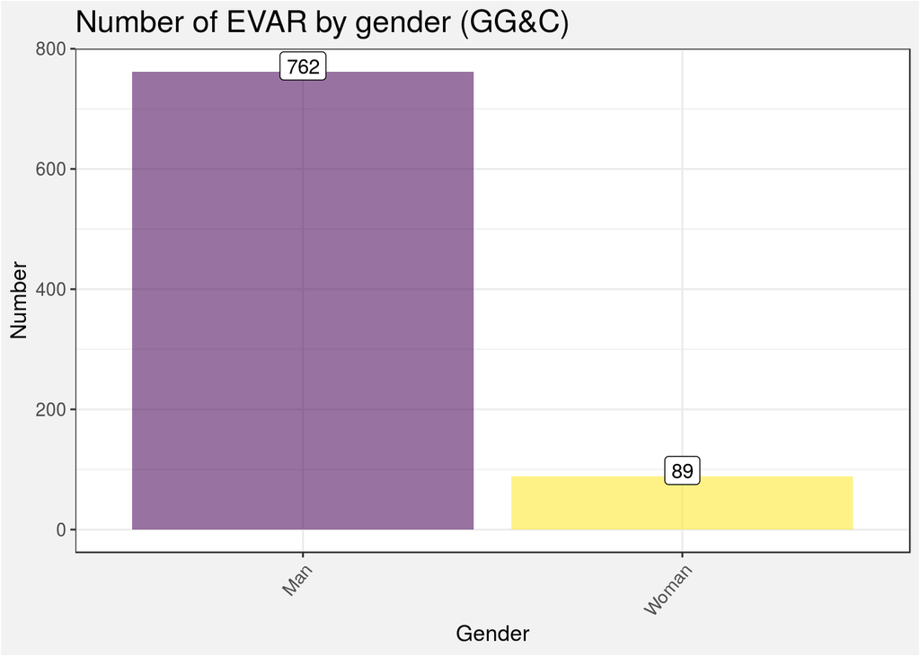

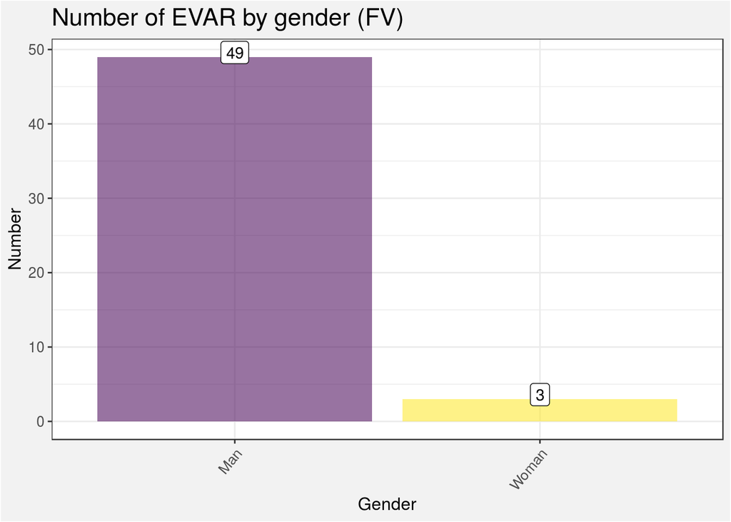

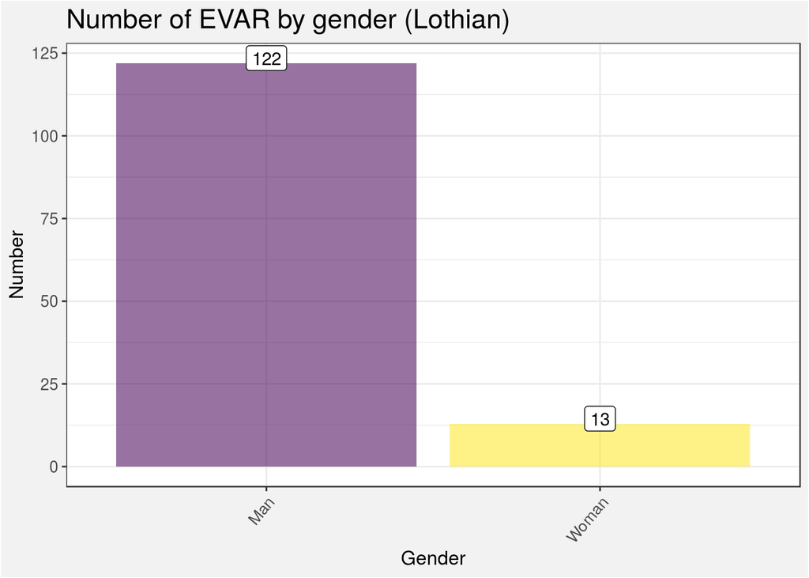

- In GG & C, 10.5% of EVAR have been performed in women
- In FV, 5.8% of EVAR have been performed in women
- In Lothian, 9.6% of EVAR have been performed in women

## 1.4 Age

### 1.4.1 Number of EVAR performed at each patient age

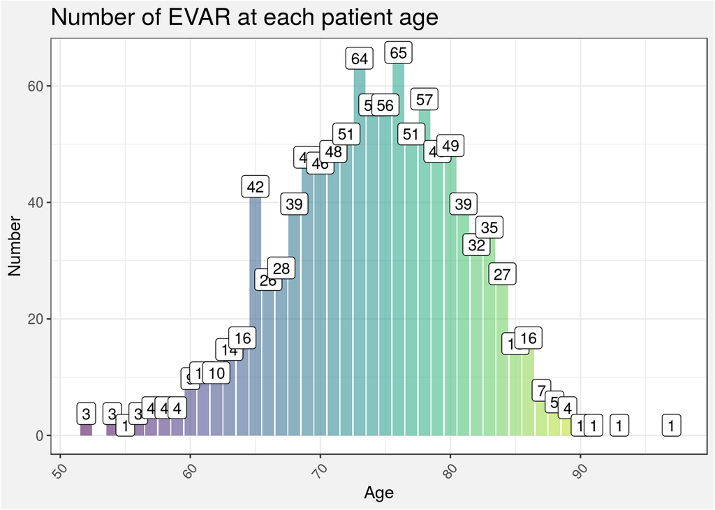

### 1.4.2 Number of EVAR performed at each patient age at each site

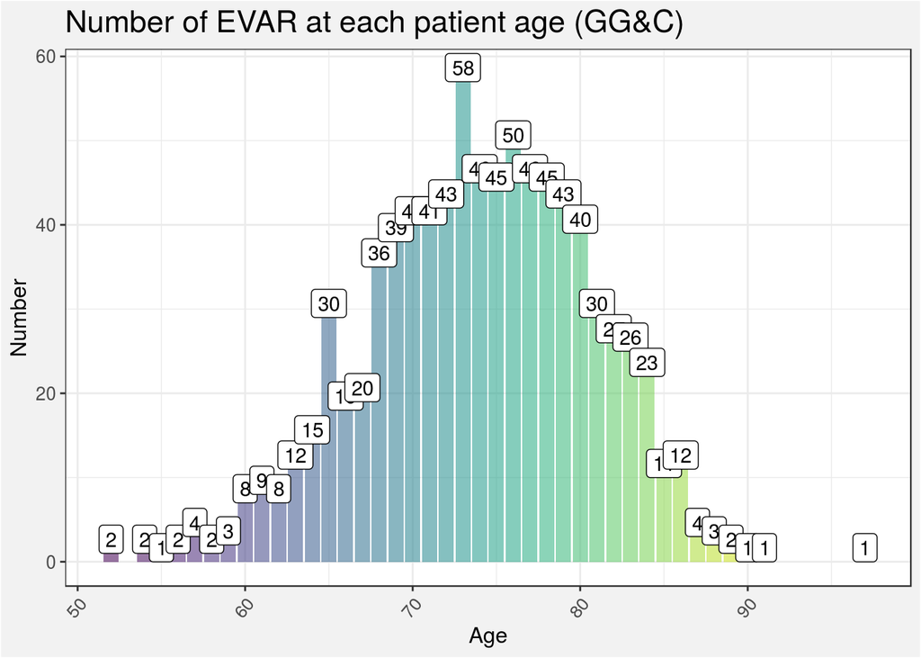

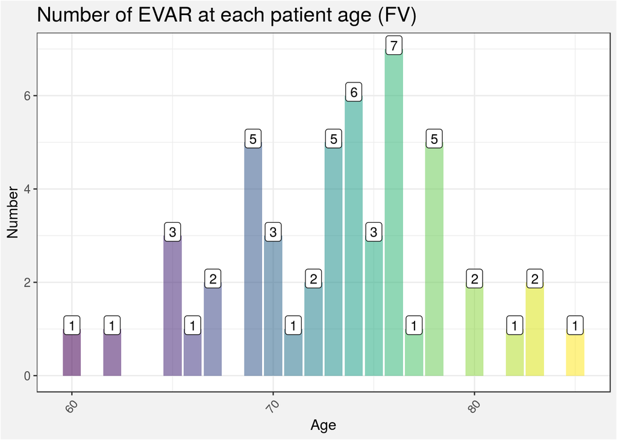

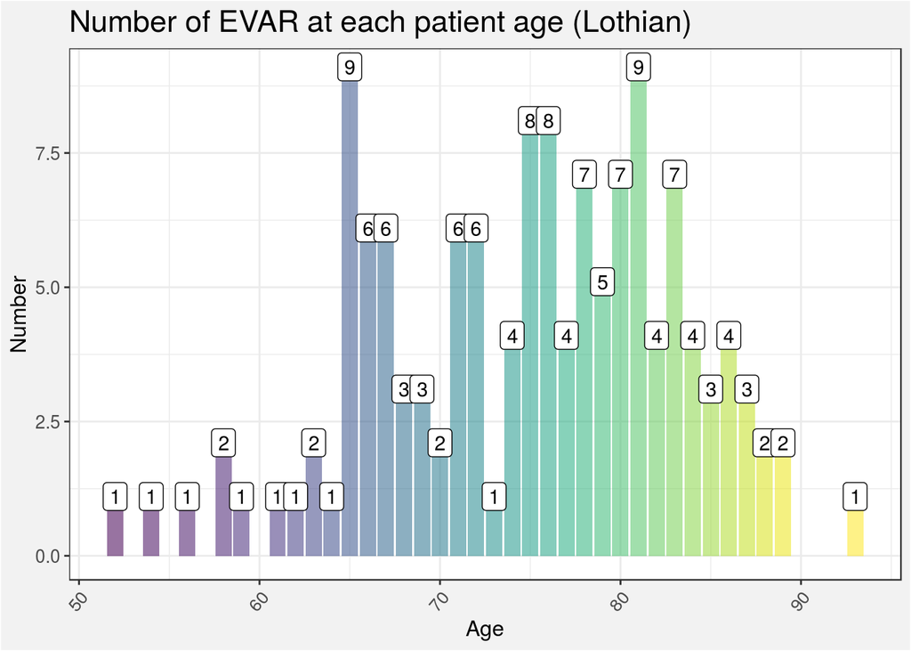

### 1.4.3 Mean and median age of patient when EVAR performed for each indication

| Indication | Median | Mean |
| --- | --- | --- |
| Elective AAA | 75 | 74.2 |
| Elective CIAA | 71 | 72.0 |
| Symptomatic AAA | 69 | 71.4 |
| Limb ischaemia | 65 | 65.4 |
| Rupture | 76 | 77.3 |
| Open repair issue | 74 | 76.9 |

### 1.4.4 Mean and median age of patient when EVAR performed for each indication at each site

| Indication | HealthBoard | Median | Mean |
| --- | --- | --- | --- |
| Elective AAA | GG & C | 74.0 | 74.1 |
| Elective AAA | FV | 74.0 | 73.5 |
| Elective AAA | Lothian | 76.0 | 74.8 |
| Elective CIAA | GG & C | 71.0 | 71.5 |
| Elective CIAA | FV | 76.0 | 75.8 |
| Symptomatic AAA | GG & C | 69.0 | 71.7 |
| Symptomatic AAA | FV | 62.0 | 62.0 |
| Symptomatic AAA | Lothian | 75.5 | 71.8 |
| Limb ischaemia | GG & C | 65.0 | 65.4 |
| Rupture | GG & C | 78.0 | 78.0 |
| Rupture | Lothian | 73.5 | 73.5 |
| Open repair issue | GG & C | 73.5 | 75.4 |
| Open repair issue | FV | 69.0 | 69.0 |
| Open repair issue | Lothian | 80.5 | 80.2 |

### 1.4.5 Boxplot of age at which EVAR was performed for each indication

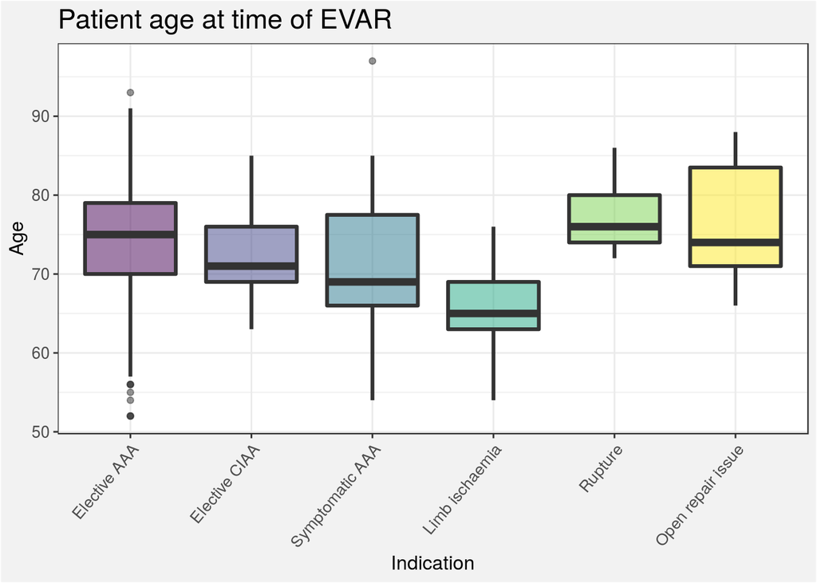

### 1.4.6 Boxplot of age at which EVAR was performed for each indication at each site

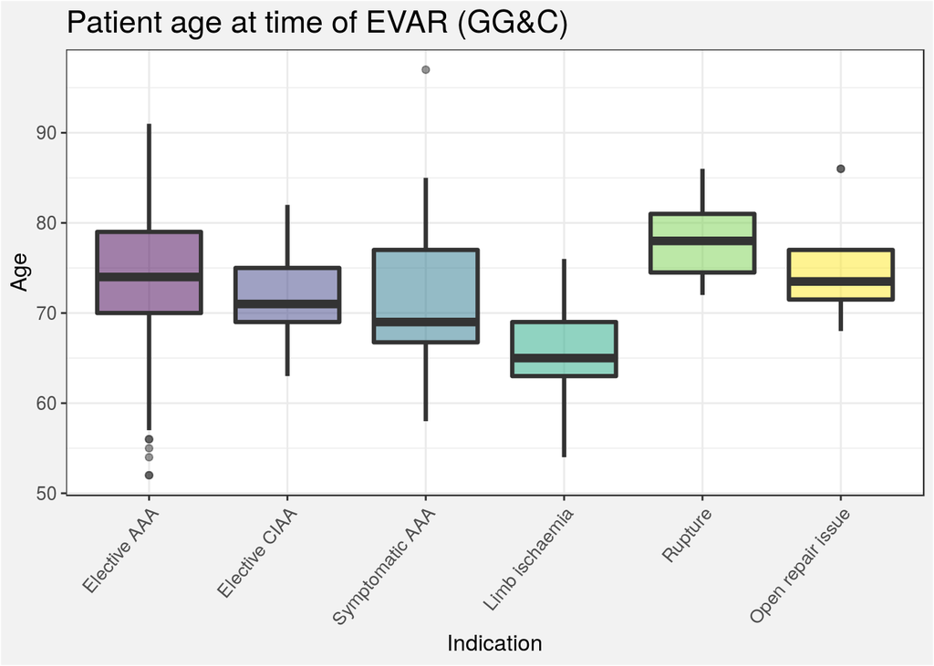

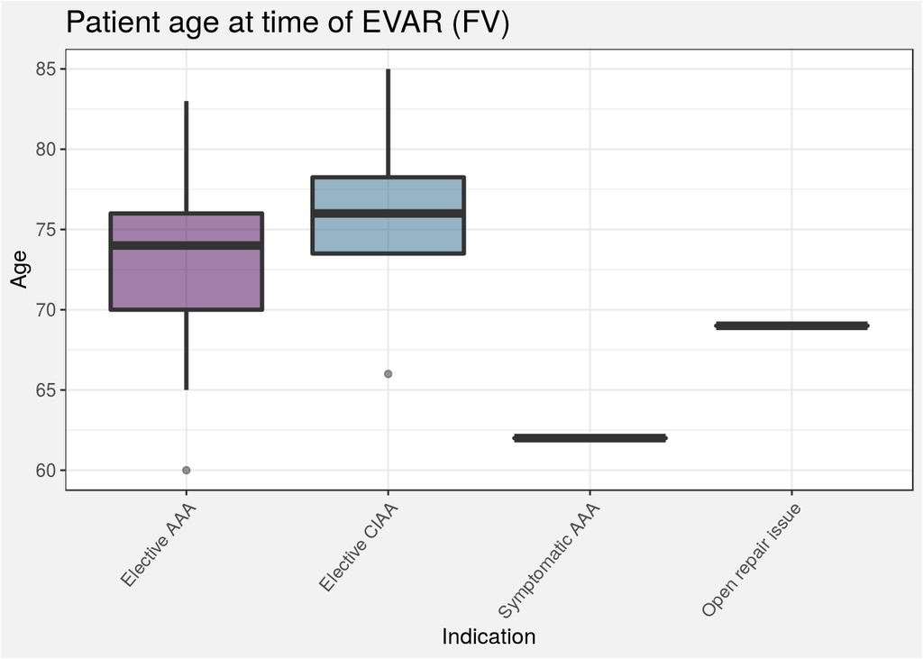

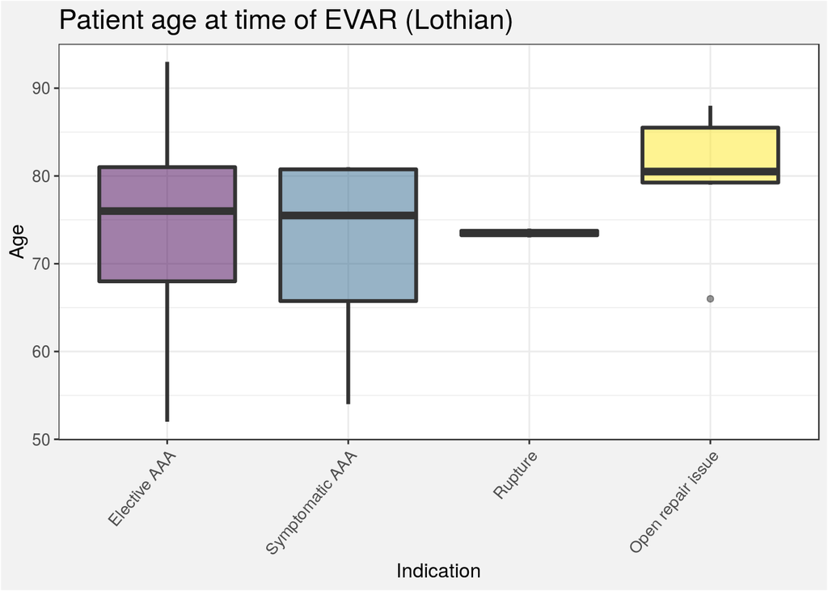

### 1.4.7 Boxplot of age at which EVAR was performed by gender

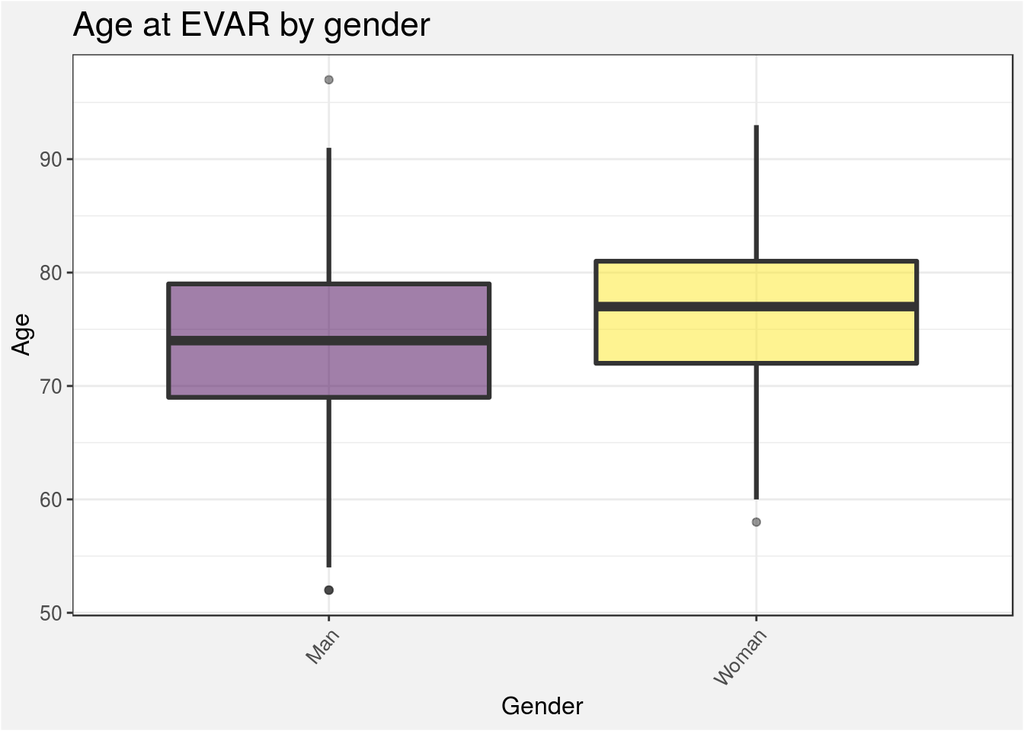

### 1.4.8 Mean and median age of patient when EVAR was performed by gender

| Gender | Median | Mean |
| --- | --- | --- |
| Man | 74 | 73.8 |
| Woman | 77 | 75.9 |

## 1.5 Year

### 1.5.1 Number of EVAR performed each year

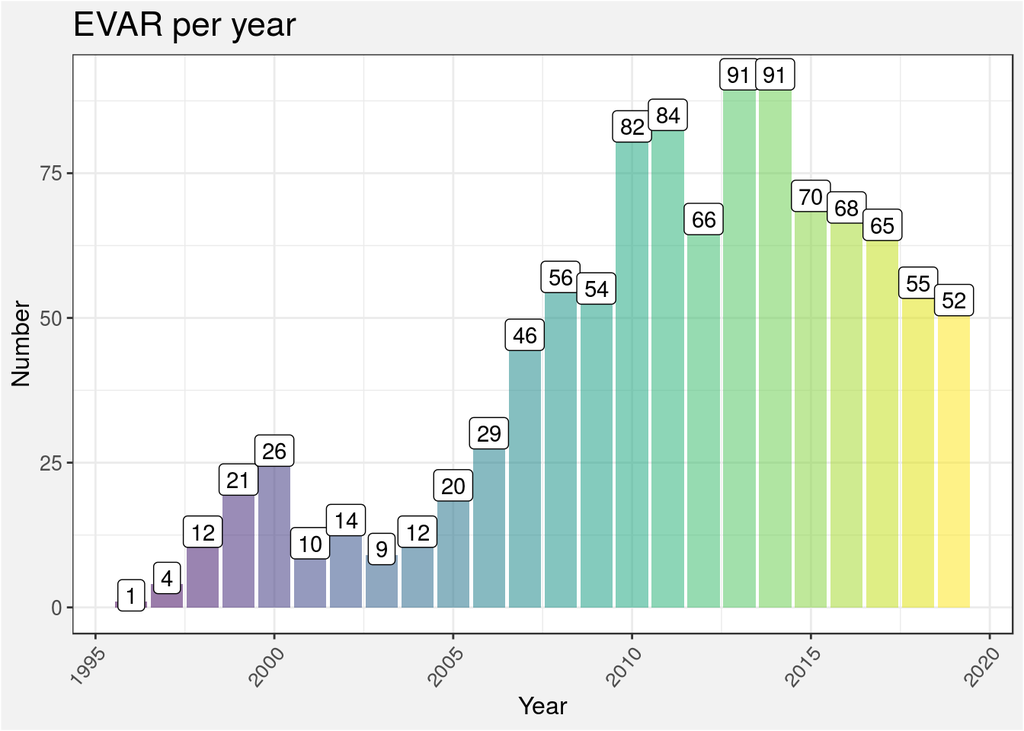

### 1.5.2 Number of EVAR performed each year at each site

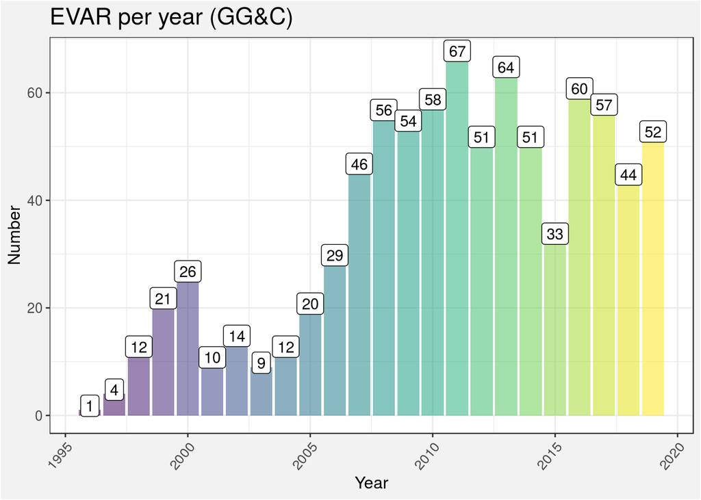

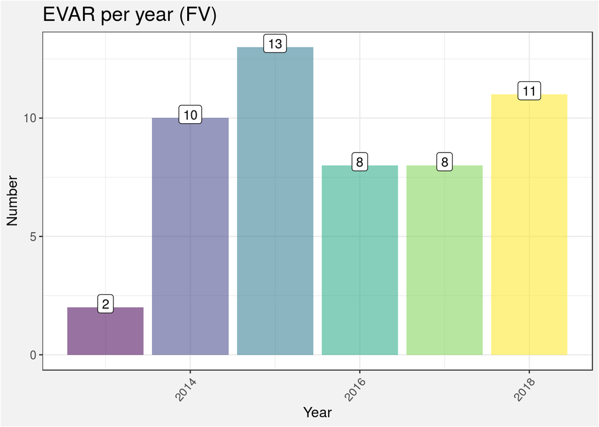

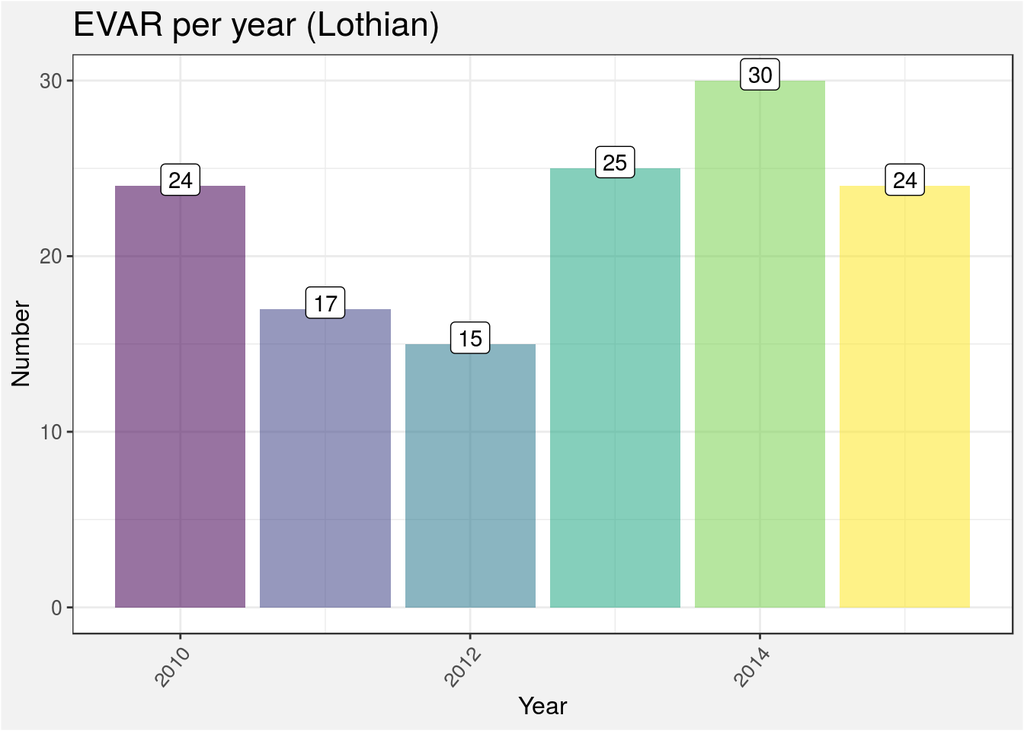

## 1.6 Year Group

- To visualise the data about years a different way, the data are grouped into ‘year groups’ of five years, eg. 2010-2014, 2015-2019 etc

### 1.6.1 Number of EVAR performed in each year group

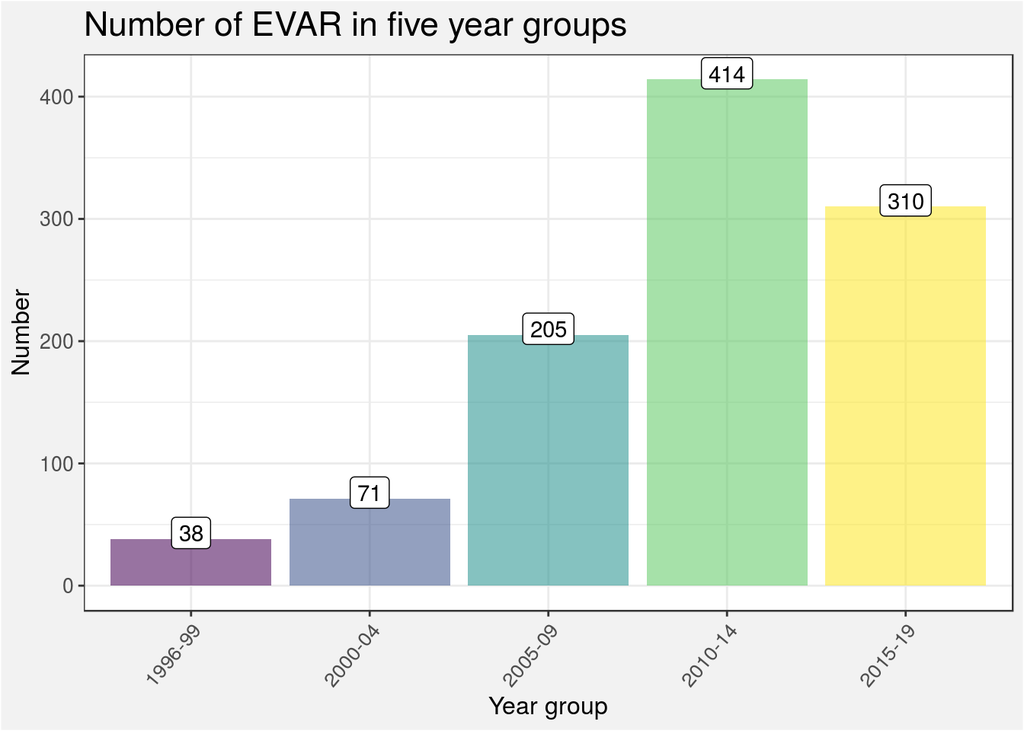

### 1.6.2 Number of EVAR performed in each year group

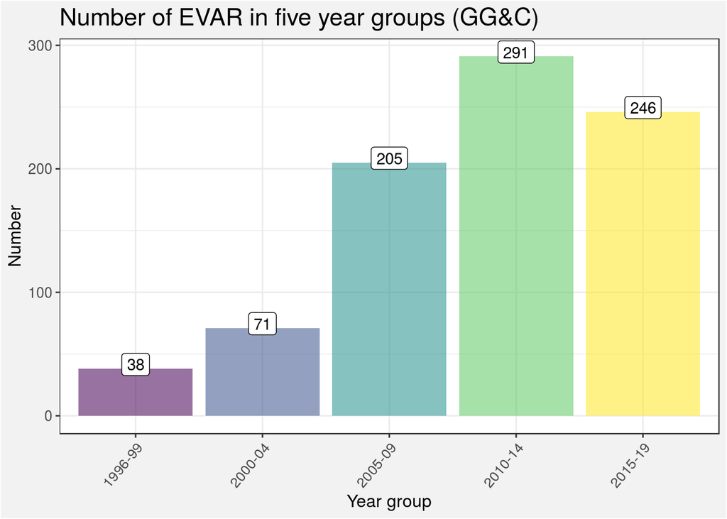

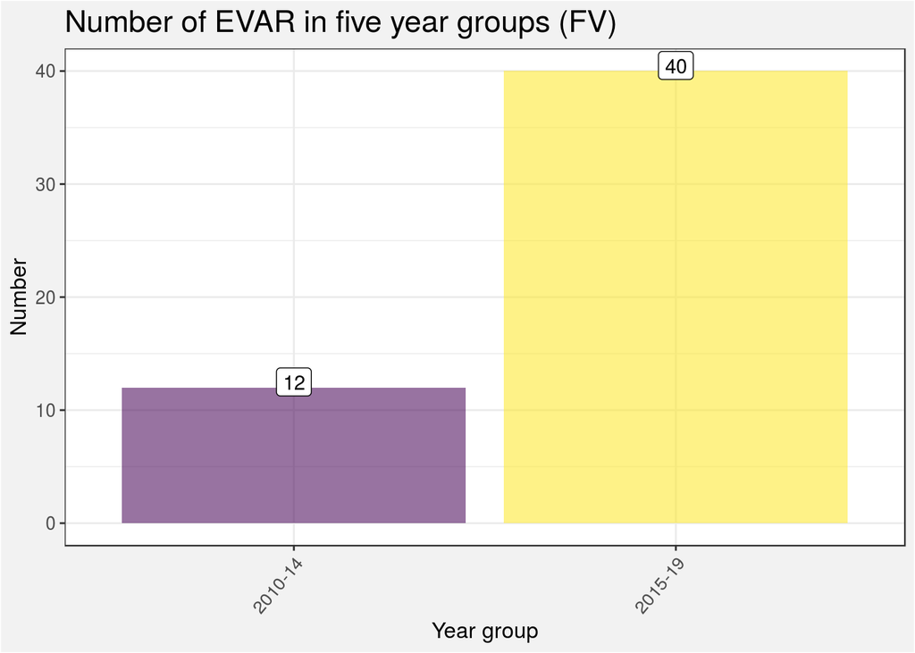

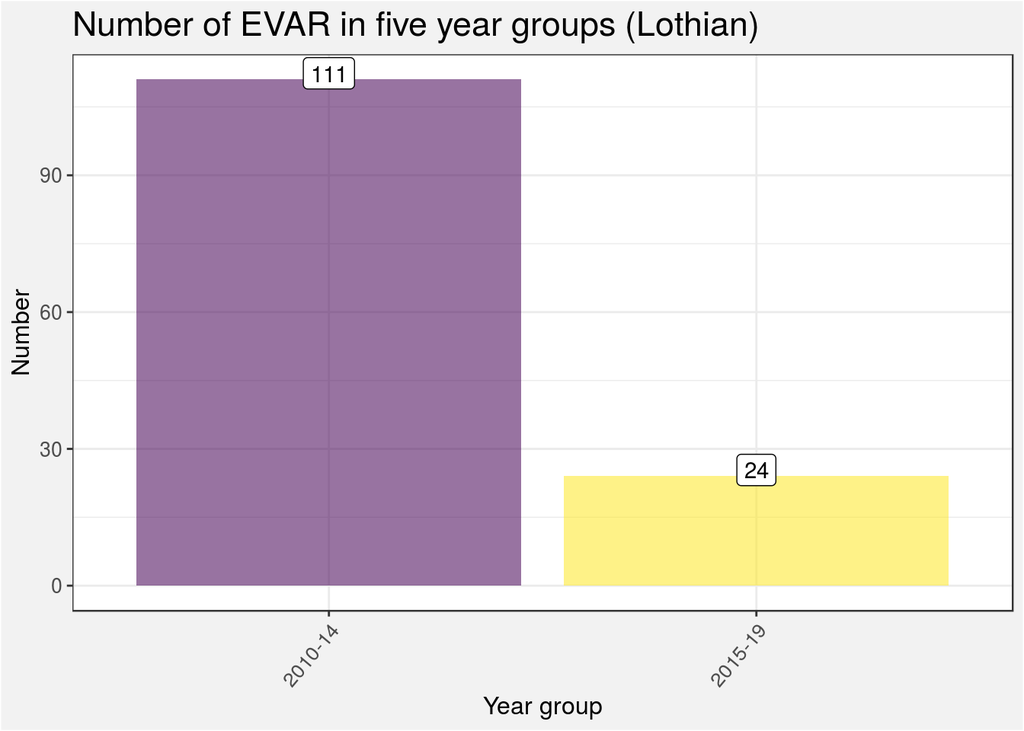

## 1.7 Stent-graft

### 1.7.1 Stent-graft used for EVAR

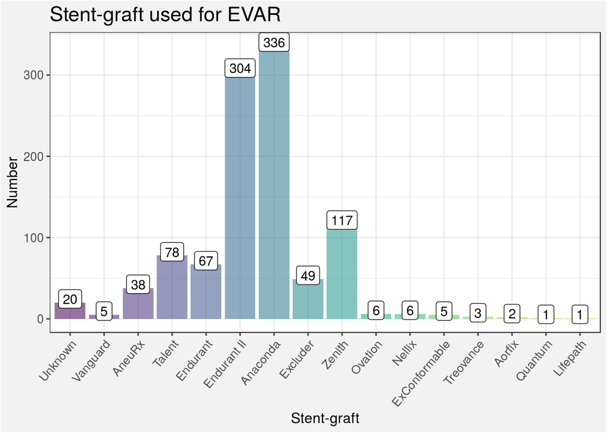

### 1.7.2 Stent-graft used for EVAR at each site

- GORE’s Excluder and Excluder Conformable devices have been combined for the following

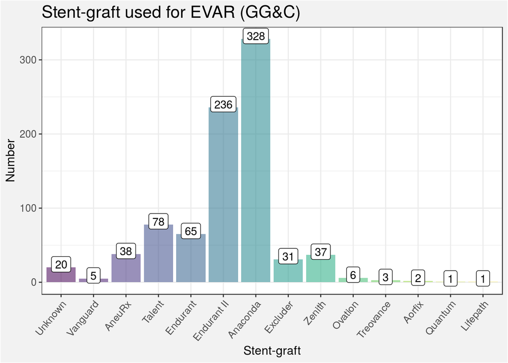

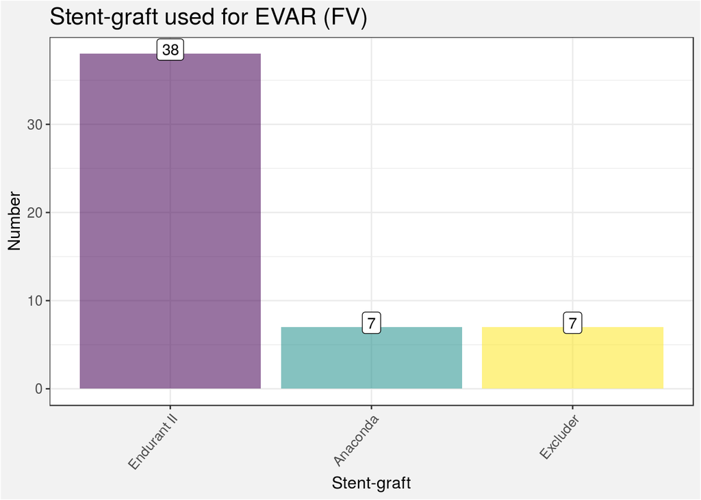

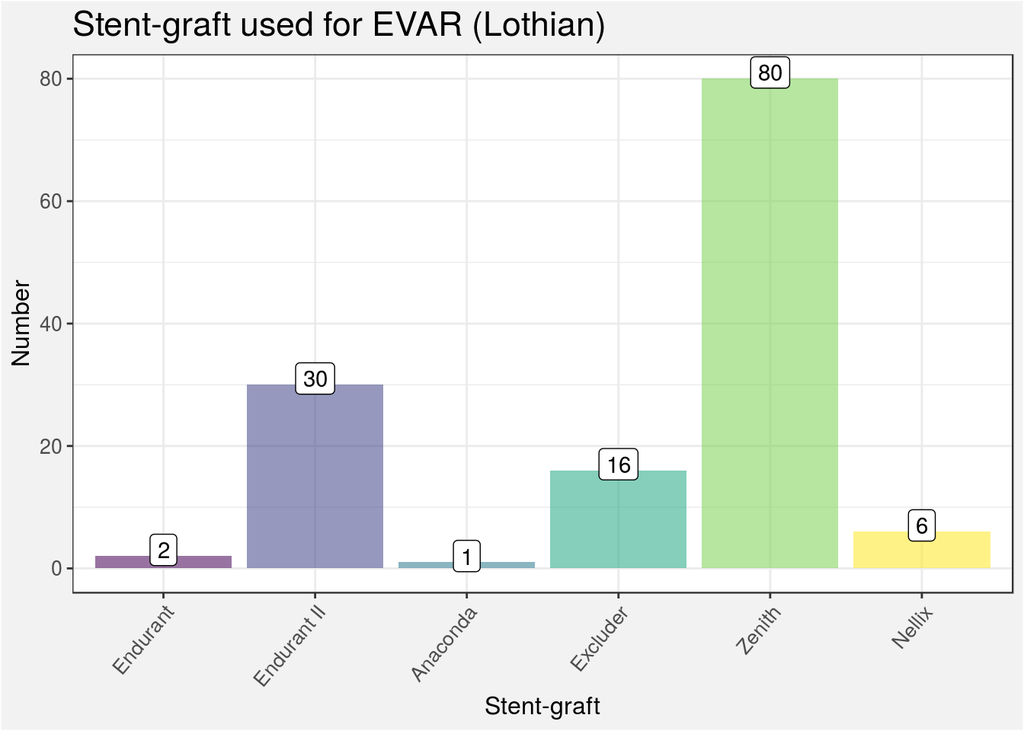

### 1.7.3 Stent-graft used for elective EVAR each year

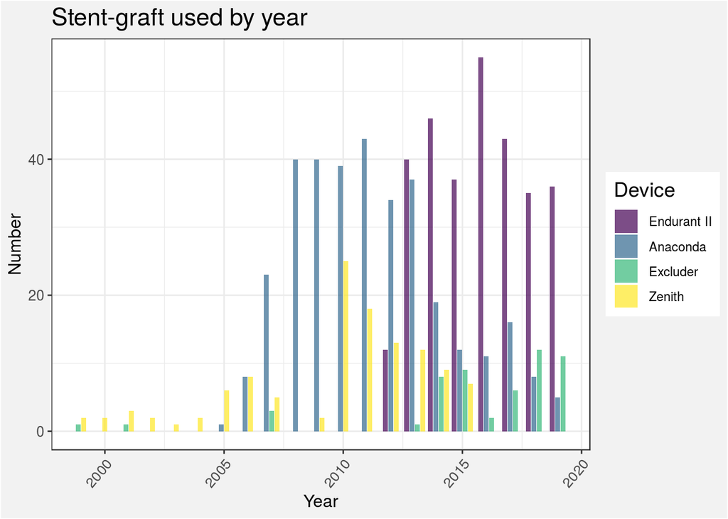

Home